# Ageing of clutch size

Eve Cooper

September 19, 2019

## Purpose

This guide demonstrates a method for investigating ageing patterns in a population using longitudinal data collected from individuals of known age. Ageing trajectories may not follow simple parametric functions and so need to be modelled using methodology that does not constrict their functional shape. However, in order to make quantitative comparisons of ageing between traits,populations, or species it is necessary to define which features of ageing to quantify and do so using standardized units of scale. We therefore take a two step approach:

1. Model the effect of age on the trait of interest non-parametrically using generalized additive mixed-models (GAMMs).
2. Using standardized estimates for each age from the GAMM, run a break-point analysis and quantify rates and durations of early-life improvements and late-life declines.

We illustrate how to control for the effects of selective (dis)appearance, variability between individuals, variability in environment, and other factors that may confound the effects of age in a wild population.

This guide uses the example of clutch size (a proxy for reproductive investment) in a wild population of Superb fairy-wrens as the trait of interest which we want to investigate ageing in.

# Packages

Load the neccessary packages and their dependencies. ‘mgcv’ is used to model GAMMs. ‘segmented’ is used for broken stick regressions.

```r
library(mgcv)
library(segmented)
library(dplyr)
```

# Dataset

We will use data collected between 1987 - 2016 on a wild population of fairy-wrens living in the Australian National Botanic Gardens. Each ID refers to a unique female. Females attempt to breed each year from age 1 and can have multiple clutches in a year. Each row in the dataframe refers to a single clutch.

```r
clutch.dat <- read.table("data/clutchSize.txt",header=TRUE)
```

## Generalized additive mixed model

Note that for a given population effects of selective (dis)appearance should not be assumed to be linear. Fitting lifespan as a spline to check the shape of the relationship was previously done. Since EDF of the lifespan spline was very close to one, a linear relationship was adequate in this case to control for potential selective disappearance in the population.

```r
#model takes about 10 - 20 minutes to run
#instead of running, just load the previously run model below
#clutch.gam<-gam(eggs~s(age,k=9)+s(julianDate)+lifespan+s(ID,bs="re")+s(year,bs="re"),data=clutch.dat,method="REML",family=quasipoisson(link="log"))
#saveRDS(clutch.gam,"clutch.gam.rds"

#alternatively, load the previously run model
clutch.gam <- readRDS("clutch.gam.rds")
```

## GAMM model review

**gam.check()**

This gives the model convergence and some diagnostic plots. Basis dimension checking results for each spline are also given. In this specific case, significant p-values for the term s(age) are not of concern since the maximum k specified for age is also the maximum degrees of freedom (9). For other spline term(s) with a k-index close to 1, models should be rerun with higher k values specified for those splines. If the residuals in the updated model are different, it’s preferable to keep the more complex model. In this specific case, higher k values did not change the model so the default k values were kept. See ‘?choose.k’ for more information.

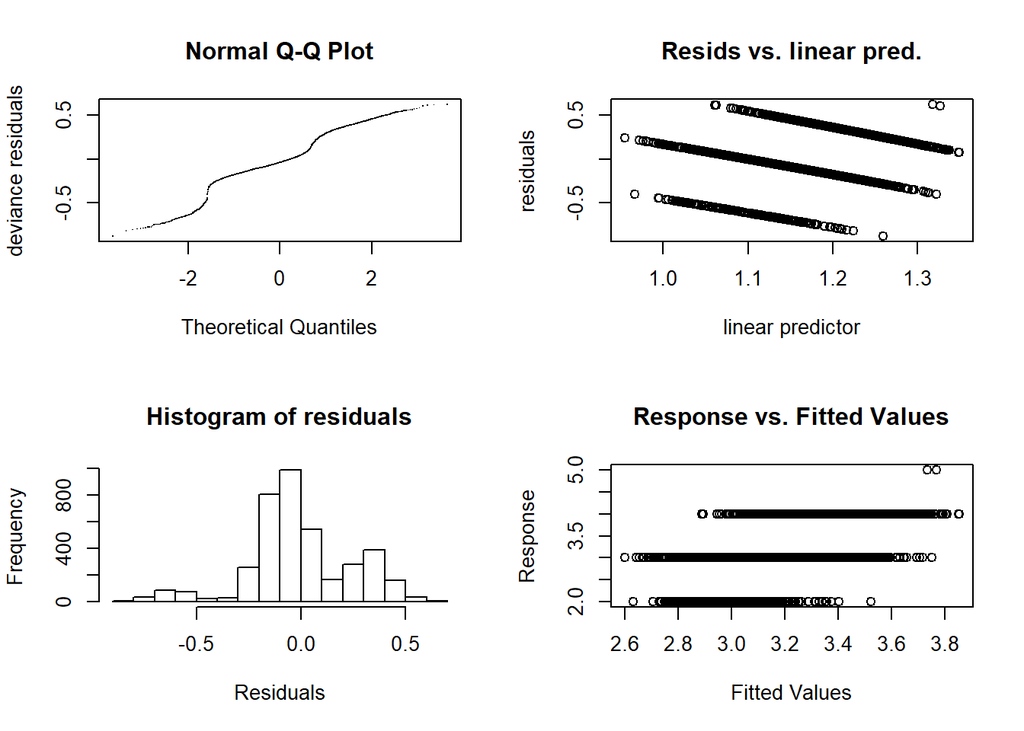

```
##
## Method: REML   Optimizer: outer newton
## full convergence after 8 iterations.
## Gradient range [-5.528896e-07,3.81231e-07]
## (score -3090.176 & scale 0.06517356).
## eigenvalue range [-2.447954e-07,1940.214].
## Model rank =  670 / 670
##
## Basis dimension (k) checking results. Low p-value (k-index<1) may
## indicate that k is too low, especially if edf is close to k'.
##
##                     k'      edf k-index p-value
## s(age)        8.00e+00 4.29e+00    0.94  <2e-16 ***
## s(julianDate) 9.00e+00 6.12e+00    0.96   0.005 **
## s(ID)         6.50e+02 2.70e+02      NA      NA
## s(year)       1.00e+00 5.38e-06    0.93  <2e-16 ***
## ---
## Signif. codes:  0 '***' 0.001 '**' 0.01 '*' 0.05 '.' 0.1 ' ' 1
```

```r
#check convergence of the model, and check that basis dimension (k) is adequate
gam.check(clutch.gam)
```

**concurvity()**

This is the GAMM equivelent to checking for colinearity in a GLMM. We can see that concurvities between fixed effects here are very small, and so nothing to worry about.

```r
concurvity(clutch.gam,full=FALSE)
```

```
## $worst
##                       para       s(age) s(julianDate)     s(ID)
## para          1.000000e+00 6.940030e-26  2.118496e-22 1.0000000
## s(age)        4.930032e-26 1.000000e+00  5.563194e-02 0.4890978
## s(julianDate) 2.118401e-22 5.563194e-02  1.000000e+00 0.1713809
## s(ID)         1.000000e+00 4.890978e-01  1.713809e-01 1.0000000
## s(year)       9.999876e-01 1.145418e-07  2.937450e-08 0.9999997
##                    s(year)
## para          9.999876e-01
## s(age)        1.145418e-07
## s(julianDate) 2.937450e-08
## s(ID)         9.999997e-01
## s(year)       1.000000e+00
##
## $observed
##                       para       s(age) s(julianDate)       s(ID)
## para          1.000000e+00 3.499555e-29  1.226708e-26 0.006579043
## s(age)        4.930032e-26 1.000000e+00  4.400031e-02 0.003984690
## s(julianDate) 2.118401e-22 4.632261e-02  1.000000e+00 0.010150582
## s(ID)         1.000000e+00 3.817687e-01  1.139947e-01 1.000000000
## s(year)       9.999876e-01 1.456379e-08  1.405679e-08 0.006594320
##                    s(year)
## para          9.999876e-01
## s(age)        1.145418e-07
## s(julianDate) 2.937450e-08
## s(ID)         9.999997e-01
## s(year)       1.000000e+00
##
## $estimate
##                       para       s(age) s(julianDate)       s(ID)
## para          1.000000e+00 7.516471e-31  8.648451e-25 0.002657946
## s(age)        4.930032e-26 1.000000e+00  2.079127e-02 0.004229922
## s(julianDate) 2.118401e-22 2.873079e-02  1.000000e+00 0.001938552
## s(ID)         1.000000e+00 4.466261e-01  1.209394e-01 1.000000000
## s(year)       9.999876e-01 7.319916e-08  5.862414e-09 0.002657034
##                    s(year)
## para          9.999876e-01
## s(age)        1.145418e-07
## s(julianDate) 2.937450e-08
## s(ID)         9.999997e-01
## s(year)       1.000000e+00
```

**model results**

Finally, we can take a look at results of our model. We can see that both age and Julian date of incubation have significant, non-linear effects on clutch size. Lifespan does not have a significant effect suggesting lifespan is not correlated with larger or smaller clutches overall.

```r
summary(clutch.gam)
```

```
##
## Family: quasipoisson
## Link function: log
##
## Formula:
## eggs ~ s(age, k = 9) + s(julianDate) + lifespan + s(ID, bs = "re") +
##     s(year, bs = "re")
##
## Parametric coefficients:
##             Estimate Std. Error t value Pr(>|t|)
## (Intercept) 1.140227   0.009379 121.568   <2e-16 ***
## lifespan    0.003273   0.002138   1.531    0.126
## ---
## Signif. codes:  0 '***' 0.001 '**' 0.01 '*' 0.05 '.' 0.1 ' ' 1
##
## Approximate significance of smooth terms:
##                     edf  Ref.df      F p-value
## s(age)        4.295e+00   5.193 16.744  <2e-16 ***
## s(julianDate) 6.121e+00   7.185 64.126  <2e-16 ***
## s(ID)         2.704e+02 648.000  0.928  <2e-16 ***
## s(year)       5.377e-06   1.000  0.000   0.291
## ---
## Signif. codes:  0 '***' 0.001 '**' 0.01 '*' 0.05 '.' 0.1 ' ' 1
##
## R-sq.(adj) =   0.22   Deviance explained = 27.3%
## -REML = -3090.2  Scale est. = 0.065174  n = 3865
```

**gam.vcomp()**

This function gives the variance (standard deviation) for each term. For the random effects, the std.dev suggests how much of the residual variance they explain. We can see here that differences between individuals (ID) explains a larger amount of variation in clutch size than environmental differences between years (year).

```r
gam.vcomp(clutch.gam)
```

```
##
## Standard deviations and 0.95 confidence intervals:
##
##                    std.dev        lower        upper
## s(age)        2.178484e-02 8.734350e-03 5.433479e-02
## s(julianDate) 5.234713e-04 2.788835e-04 9.825687e-04
## s(ID)         5.829804e-02 5.134252e-02 6.619584e-02
## s(year)       1.138819e-06 1.111537e-06 1.166771e-06
## scale         2.572022e-01 2.510406e-01 2.635150e-01
##
## Rank: 4/5
```

**plot results**

We can plot the results of our GAMM to visualize the ageing tragectory of clutch size. Specifying ‘seWithMean=2’ includes uncertainty about the overall mean from other variables in the model, excluding random effects.

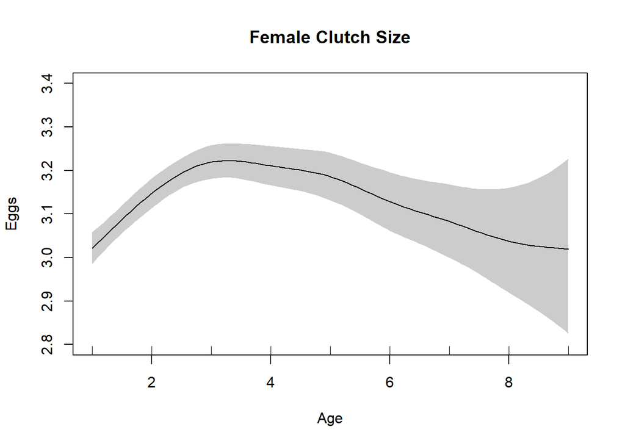

```r
plot(clutch.gam,select=1,seWithMean=2,shade=TRUE,trans=exp,shift=coef(clutch.gam)[1],main="Female Clutch Size",
     ylab="Eggs",xlab="Age",ylim=c(2.8,3.4))
```

# Quantify ageing trajectories

We can see from the GAMM graph that it appears that clutch size increases in early ages, plateaus, and then declines at late ages. However, if we want to quantify the rates of these increases and decreases, a second step is neccessary. Now we will:

- extract age-specific estimates of clutch size for each age from the GAMM
- standardize these estimates by z-transforming them. This allows direct comparison of ageing between traits, populations, or species
- run a simple linear model using these standardized estimates
- use the package ‘?segmented’ to test for a breakpoint in the linear model

This process allows for us to identify and quantify the rate and significance any early-life improvement (maturation) as well as late-life decline (senescence). If late-life declines are significant, breakpoint analysis indicates the age of onset of senescence.

First we extract the estimates from the GAMM and standardize them.

```r
#pull estimates
pred.clutch<-data.frame(x=predict.gam(clutch.gam,type="iterms",se.fit=TRUE))
#create a new clutch data table excluding individuals without lifespan (since they're excluded from model)
clutch.datS<-clutch.dat %>%
  filter(!is.na(lifespan))
#add age column
pred.clutch$age <- clutch.datS$age
#summarize data for each age class
sum.clutch <-pred.clutch %>%
  group_by(age) %>%
  summarize(x=mean(x.fit.s.age.),se=mean(x.se.fit.s.age.))

#z-transform
#extract the GAMM model estimates again, this time specifying type='link' so that the linear predictor incorporating all terms in the model is returned
pred.link<-data.frame(x=predict.gam(clutch.gam,type="link",se.fit=TRUE))
#now center each prediction on the mean prediction for the effect of age, divided by the range of predictions in the overall model
clutch.reg<-sum.clutch %>%
  mutate(xz=(x-mean(sum.clutch$x))/(max(pred.link$x.fit)-min(pred.link$x.fit)))%>%
  mutate(xz=xz*10) #we multiplied our predictions by 10 for ease on interpretability, this step is entirely optional
```

Run a linear model using these standardized estimates. Weight the model by the inverse of the standard error. This ensures that estimate precision is accounted for (while at the same time not allowing the much larger sample size at lower ages in the GAMMs entirely drive the regression prediction).

```r
summary(lm.clutch<-lm(xz~age,weights = 1/se, data=clutch.reg))
```

```
##
## Call:
## lm(formula = xz ~ age, data = clutch.reg, weights = 1/se)
##
## Weighted Residuals:
##      Min       1Q   Median       3Q      Max
## -12.4118  -4.9977  -0.3778   4.4660   8.5452
##
## Coefficients:
##              Estimate Std. Error t value Pr(>|t|)
## (Intercept)  0.195576   0.451649   0.433    0.678
## age         -0.009472   0.101576  -0.093    0.928
##
## Residual standard error: 7.234 on 7 degrees of freedom
## Multiple R-squared:  0.001241,   Adjusted R-squared:  -0.1414
## F-statistic: 0.008696 on 1 and 7 DF,  p-value: 0.9283
```

From the linear model results, we can see that there is no effect of age on clutch size when we constrain the relationship to a single linear slope.

Now, we can test if there is a significant breakpoint in the model using a Davies test. This tests for a non-zero difference in slopes if the linear model were broken into two linear models, at multiple points in the model. Essentially it is testing if the relationship between age and clutch size might be better explained by two segmented/broken linear models, rather than one. We set k (the number of points where the test should be evaluated) to n-2 so that it’s only evaluating breakpoints at integers. See ‘?davies.test’ for details.

```r
davies.test(lm.clutch,seg.Z =~age, k=7)
```

```
##
##  Davies' test for a change in the slope
##
## data:  formula = xz ~ age ,   method = lm
## model = gaussian , link = identity
## segmented variable = age
## 'best' at = 3, n.points = 7, p-value = 0.0003363
## alternative hypothesis: two.sided
```

The small p-value of the davies test indicates a high probability that there is a difference between slopes of a segmented model. In other words, it indicates that two seperate linear models might better describe this ageing pattern than one.

The function segmented() implements a bootstrap restarting algorithm to find the breakpoint in the linear model that with result in the largest difference in the slopes of the resulting two models. See ‘?segmented’ for details.

```r
summary(seg.clutch<-segmented(lm.clutch))
```

```
##
##  ***Regression Model with Segmented Relationship(s)***
##
## Call:
## segmented.lm(obj = lm.clutch)
##
## Estimated Break-Point(s):
##           Est. St.Err
## psi1.age 3.21  0.133
##
## Meaningful coefficients of the linear terms:
##             Estimate Std. Error t value Pr(>|t|)
## (Intercept) -1.50038    0.15527  -9.663 0.000201 ***
## age          0.80276    0.07188  11.169 0.000100 ***
## U1.age      -1.14671    0.08128 -14.107       NA
## ---
## Signif. codes:  0 '***' 0.001 '**' 0.01 '*' 0.05 '.' 0.1 ' ' 1
##
## Residual standard error: 1.311 on 5 degrees of freedom
## Multiple R-Squared: 0.9766,  Adjusted R-squared: 0.9625
##
## Convergence attained in 2 iter. (rel. change 2.0425e-16)
```

The summary function tells us the breakpoint estimated by the function (3.21). Note that the estimate of ‘U1.age’ is not the slope of age in later life, it’s the difference in the slope of age between early and late life.

To find the slopes of the two regressions we use slope().

```r
slope(seg.clutch)
```

```
## $age
##            Est.  St.Err. t value CI(95%).l CI(95%).u
## slope1  0.80276 0.071877 11.1690   0.61799   0.98752
## slope2 -0.34396 0.037959 -9.0613  -0.44153  -0.24638
```

‘slope1’ refers to the slope of the regression from ages 1 - 3.21. ‘slope2’ refers to the slope of the regression in ages beyond 3.21.

Our results demonstrate a significant trend of improvement (increased clutch size) in early life up until age 3.21, followed by significant senescent declines in clutch size after that age.

A graph will help to illustrate what this pattern looks like:

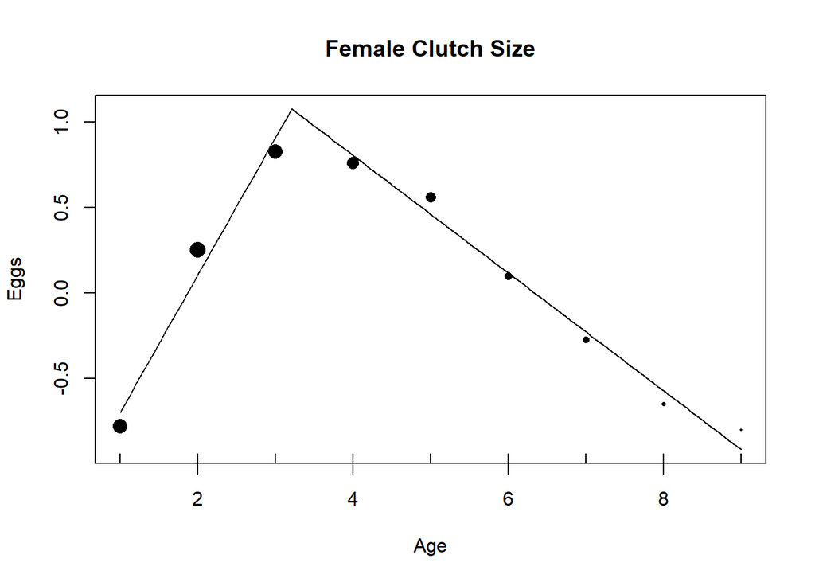

```r
plot.segmented(seg.clutch,xlab="Age",ylab="Eggs")
title(main="Female Clutch Size")
#optionally, we can also add the data points used in the model. I've sized them here relative to their weight in the model.
points(xz~age,data=clutch.reg,pch=16,cex=1/clutch.reg$se*0.01) #se is multiplied by 0.01 simply to achieve an attractive point size for the graph
```